# Establishment

Justine Floret

2024-07-11

## Library and Data preparation

```r
library(readr)
library(dplyr)
library(tidyr)
library(tidyverse)
library(reshape2) #melt function
library(forcats) #reorganise in geom boxplot
library(kableExtra) # Markdown table

# Stat library
# library(lme4)
library(lmerTest) #glht
# library(MASS)
library(lsmeans) #pairwise comparison
library(multcomp)  #glht
library(multcompView)  #glht
library(rstatix) # manova levene test

# Graphic library
library(GGally) #ppair plot
library(ggplot2)
library(viridis)
library(svglite) # save in svg format
library(corrplot)

colors <- c("#6ece58", "#22a884", "#355f8d","#440154")

data_all <- read_csv("/home/justine/sciebo/1_Populations/2_assay/dataset/Phenology_field.csv")

data_all$Site_ID <- as.factor(data_all$Site_ID)
data_all$Area <- as.factor(data_all$Area)
data_all$Localization_ID <- as.factor(data_all$Localization_ID)
data_all$Type <- as.factor(data_all$Type)
data_all$Destroyed <- as.factor(data_all$Destroyed)
data_all$Outliers_soil <- as.factor(data_all$Outliers_soil)
data_all$Sowing_1st <- as.factor(data_all$Sowing_1st)
data_all$Sowing_2nd <- as.factor(data_all$Sowing_2nd)
data_all$Germ_2ndyear <- as.factor(data_all$Germ_2ndyear)
data_all$Presence_April_22 <- as.factor(data_all$Presence_April_22)
data_all$Presence_April_23 <- as.factor(data_all$Presence_April_23)
data_all$Presence_April_24 <- as.factor(data_all$Presence_April_24)
```

Data summary

```r
data_all %>% count(Type) # tot number of site sowed
```

```
## # A tibble: 4 × 2
##   Type         n
##   <fct>    <int>
## 1 grass      147
## 2 pavement   144
## 3 Tree bed   107
## 4 wall        93
```

```r
data_all %>% dplyr::group_by(Sowing_1st) %>% count(Type)
```

```
## # A tibble: 8 × 3
## # Groups:   Sowing_1st [2]
##   Sowing_1st Type         n
##   <fct>      <fct>    <int>
## 1 07/2022    grass       10
## 2 07/2022    pavement    20
## 3 07/2022    Tree bed     1
## 4 07/2022    wall        46
## 5 09/2021    grass      137
## 6 09/2021    pavement   124
## 7 09/2021    Tree bed   106
## 8 09/2021    wall        47
```

```r
data_all %>% dplyr::group_by(Sowing_1st, Type) %>% count(Destroyed)  # site destroyed
```

```
## # A tibble: 16 × 4
## # Groups:   Sowing_1st, Type [8]
##    Sowing_1st Type     Destroyed     n
##    <fct>      <fct>    <fct>     <int>
##  1 07/2022    grass    Exist        10
##  2 07/2022    pavement Exist        20
##  3 07/2022    Tree bed Exist         1
##  4 07/2022    wall     04/2023       2
##  5 07/2022    wall     Exist        44
##  6 09/2021    grass    02/2022      16
##  7 09/2021    grass    04/2024       2
##  8 09/2021    grass    09/2022       3
##  9 09/2021    grass    10/2022      10
## 10 09/2021    grass    Exist       106
## 11 09/2021    pavement 02/2022       5
## 12 09/2021    pavement Exist       119
## 13 09/2021    Tree bed 05/2022       1
## 14 09/2021    Tree bed 10/2022       1
## 15 09/2021    Tree bed Exist       104
## 16 09/2021    wall     Exist        47
```

```r
data_all %>% dplyr::group_by(Sowing_2nd) %>% count(Type)  # site resown in July 2022
```

```
## # A tibble: 6 × 3
## # Groups:   Sowing_2nd [2]
##   Sowing_2nd Type         n
##   <fct>      <fct>    <int>
## 1 07/2022    pavement    19
## 2 07/2022    Tree bed     6
## 3 no         grass      147
## 4 no         pavement   125
## 5 no         Tree bed   101
## 6 no         wall        93
```

## April 2022

### September 2021 sowing only

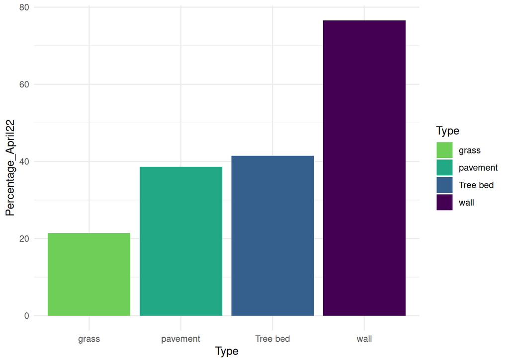

```r
# Number of site after removing the destroyed site before 03/2022
establishment <- as.data.frame( data_all %>% dplyr::filter(Destroyed == "Exist" | Destroyed =="05/2022" | Destroyed =="09/2022" | Destroyed =="10/2022" | Destroyed =="04/2023"| Destroyed =="04/2024") %>%
  dplyr::filter(Sowing_1st =="09/2021") %>% count(Type))

colnames(establishment) <- c("Type", "Site_April22")

# Established sites
tmp <- as.data.frame(data_all %>% dplyr::filter(Destroyed == "Exist" | Destroyed =="05/2022" | Destroyed =="09/2022" | Destroyed =="10/2022" | Destroyed =="04/2024") %>%
  dplyr::filter(Sowing_1st =="09/2021") %>% dplyr::filter(Presence_April_22 == "Yes") %>% count(Type))
establishment$Established_April22 <- tmp[,2]

# Percentage of establishment
establishment$Percentage_April22 <- round(establishment$Established_April22 / establishment$Site_April22 * 100, digit = 2)

ggplot(establishment, aes(x = Type, y=Percentage_April22, fill = Type )) + geom_bar(stat = "identity") +
  theme_minimal() + scale_fill_manual(values=colors)
```

```r
#ggsave("Establishment_April22_S1",device = "svg" ,dpi=900)
#ggsave("/home/justine/sciebo/Paper_urban_niche/Figures/Establishment_April22_S1", plot = last_plot(),dpi = 900, device = "svg", bg = "transparent")
```

#### Model Presence/absence

```r
April_22 <- as.data.frame( data_all %>% dplyr::filter(Destroyed == "Exist" | Destroyed =="05/2022" | Destroyed =="09/2022" | Destroyed =="10/2022" | Destroyed =="04/2023"| Destroyed =="04/2024") %>%
                 dplyr::filter(Sowing_1st =="09/2021"))

modnul <- glm(Presence_April_22 ~ 1, data = April_22 ,family = binomial)

mod1 <- glm(Presence_April_22 ~ Type, data = April_22 ,family = binomial)
summary(mod1)
```

```
##
## Call:
## glm(formula = Presence_April_22 ~ Type, family = binomial, data = April_22)
##
## Coefficients:
##              Estimate Std. Error z value Pr(>|z|)
## (Intercept)   -1.2958     0.2213  -5.854 4.79e-09 ***
## Typepavement   0.8340     0.2906   2.870  0.00410 **
## TypeTree bed   0.9528     0.2964   3.215  0.00131 **
## Typewall       2.4814     0.4095   6.060 1.36e-09 ***
## ---
## Signif. codes:  0 '***' 0.001 '**' 0.01 '*' 0.05 '.' 0.1 ' ' 1
##
## (Dispersion parameter for binomial family taken to be 1)
##
##     Null deviance: 524.48  on 392  degrees of freedom
## Residual deviance: 479.74  on 389  degrees of freedom
## AIC: 487.74
##
## Number of Fisher Scoring iterations: 4
```

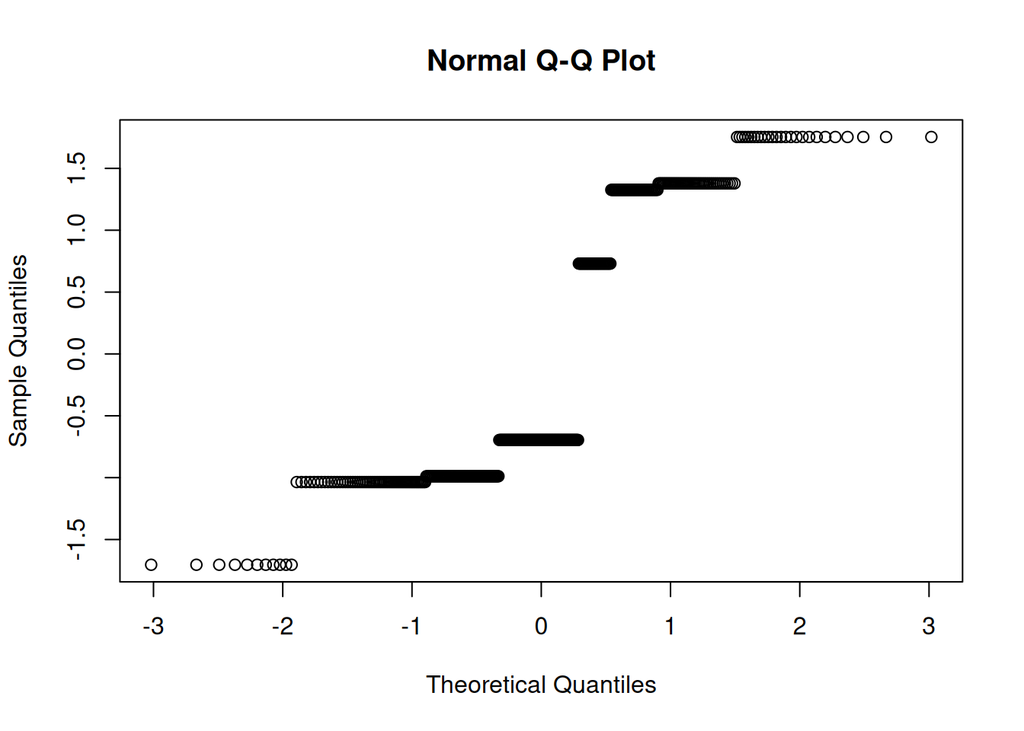

```r
qqnorm(resid(mod1))
```

```r
mod2 <- glm(Presence_April_22 ~ Type, data = April_22 ,family = quasibinomial)
summary(mod2)
```

```
##
## Call:
## glm(formula = Presence_April_22 ~ Type, family = quasibinomial,
##     data = April_22)
##
## Coefficients:
##              Estimate Std. Error t value Pr(>|t|)
## (Intercept)   -1.2958     0.2225  -5.825 1.20e-08 ***
## Typepavement   0.8340     0.2921   2.856  0.00453 **
## TypeTree bed   0.9528     0.2979   3.198  0.00149 **
## Typewall       2.4814     0.4116   6.029 3.84e-09 ***
## ---
## Signif. codes:  0 '***' 0.001 '**' 0.01 '*' 0.05 '.' 0.1 ' ' 1
##
## (Dispersion parameter for quasibinomial family taken to be 1.010283)
##
##     Null deviance: 524.48  on 392  degrees of freedom
## Residual deviance: 479.74  on 389  degrees of freedom
## AIC: NA
##
## Number of Fisher Scoring iterations: 4
```

```r
qqnorm(resid(mod2))

anova(modnul, mod1, mod2,test="LRT")
```

```
## Analysis of Deviance Table
##
## Model 1: Presence_April_22 ~ 1
## Model 2: Presence_April_22 ~ Type
## Model 3: Presence_April_22 ~ Type
##   Resid. Df Resid. Dev Df Deviance  Pr(>Chi)
## 1       392     524.48
## 2       389     479.74  3   44.747 1.047e-09 ***
## 3       389     479.74  0    0.000
## ---
## Signif. codes:  0 '***' 0.001 '**' 0.01 '*' 0.05 '.' 0.1 ' ' 1
```

```r
car::Anova(mod1)
```

```
## Analysis of Deviance Table (Type II tests)
##
## Response: Presence_April_22
##      LR Chisq Df Pr(>Chisq)
## Type   44.747  3  1.047e-09 ***
## ---
## Signif. codes:  0 '***' 0.001 '**' 0.01 '*' 0.05 '.' 0.1 ' ' 1
```

```r
car::Anova(mod1, test.statistic="F")
```

```
## Analysis of Deviance Table (Type II tests)
##
## Response: Presence_April_22
## Error estimate based on Pearson residuals
##
##           Sum Sq  Df F value    Pr(>F)
## Type       44.75   3  14.764 4.012e-09 ***
## Residuals 393.00 389
## ---
## Signif. codes:  0 '***' 0.001 '**' 0.01 '*' 0.05 '.' 0.1 ' ' 1
```

```r
leastsquare = lsmeans(mod1, pairwise ~ Type,adjust = "tukey")
cld(leastsquare)
```

```
##  Type     lsmean    SE  df asymp.LCL asymp.UCL .group
##  grass    -1.296 0.221 Inf    -1.730   -0.8620  1
##  pavement -0.462 0.188 Inf    -0.831   -0.0929   2
##  Tree bed -0.343 0.197 Inf    -0.729    0.0434   2
##  wall      1.186 0.345 Inf     0.510    1.8608    3
##
## Results are given on the logit (not the response) scale.
## Confidence level used: 0.95
## Results are given on the log odds ratio (not the response) scale.
## P value adjustment: tukey method for comparing a family of 4 estimates
## significance level used: alpha = 0.05
## NOTE: If two or more means share the same grouping symbol,
##       then we cannot show them to be different.
##       But we also did not show them to be the same.
```

## April 2023

### September 2021 sowing only

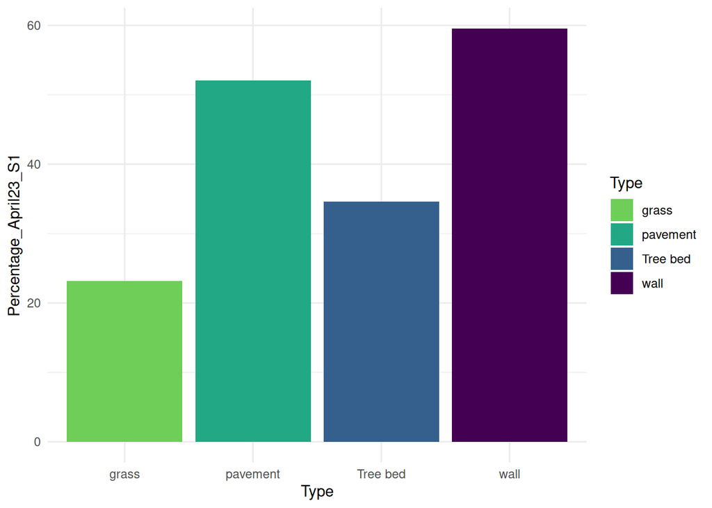

```r
# Number of site after removing the destroyed site before 05/2023
tmp <- as.data.frame( data_all %>% dplyr::filter(Destroyed == "Exist" | Destroyed =="04/2024") %>%
                 dplyr::filter(Sowing_1st =="09/2021") %>% count(Type))
establishment$Site_April23_S1 <- tmp[,2]

# Established sites
tmp <- as.data.frame(data_all %>% dplyr::filter(Destroyed == "Exist" | Destroyed =="04/2024") %>%
                       dplyr::filter(Sowing_1st =="09/2021") %>% dplyr::filter(Presence_April_23 == "Yes") %>% count(Type))
establishment$Established_April23_S1 <- tmp[,2]


tmp <- as.data.frame(data_all %>% dplyr::filter(Destroyed == "Exist" | Destroyed =="04/2024") %>%
                       dplyr::filter(Sowing_1st =="07/2022") %>% dplyr::filter(Presence_April_23 == "Yes") %>% count(Type))
establishment$Established_April23_S2 <- tmp[,2]

# Percentage of establishment
establishment$Percentage_April23_S1 <- round(establishment$Established_April23_S1 / establishment$Site_April23_S1 * 100, digit = 2)

ggplot(establishment, aes(x = Type, y=Percentage_April23_S1, fill = Type)) + geom_bar(stat = "identity") +
  theme_minimal() + scale_fill_manual(values=colors)
```

Model Presence/absence

```r
April_23 <- as.data.frame( data_all %>% dplyr::filter(Destroyed == "Exist"| Destroyed =="04/2024") %>%
                             dplyr::filter(Sowing_1st =="09/2021") %>% dplyr::filter(Sowing_2nd =="no"))

mod1 <- glm(Presence_April_23 ~ Type, data = April_23 ,family = binomial)
summary(mod1)
```

```
##
## Call:
## glm(formula = Presence_April_23 ~ Type, family = binomial, data = April_23)
##
## Coefficients:
##              Estimate Std. Error z value Pr(>|z|)
## (Intercept)   -1.2000     0.2281  -5.260 1.44e-07 ***
## Typepavement   1.0396     0.3038   3.422 0.000622 ***
## TypeTree bed   0.4293     0.3150   1.363 0.172982
## Typewall       1.5877     0.3747   4.237 2.26e-05 ***
## ---
## Signif. codes:  0 '***' 0.001 '**' 0.01 '*' 0.05 '.' 0.1 ' ' 1
##
## (Dispersion parameter for binomial family taken to be 1)
##
##     Null deviance: 464.57  on 352  degrees of freedom
## Residual deviance: 440.60  on 349  degrees of freedom
## AIC: 448.6
##
## Number of Fisher Scoring iterations: 4
```

```r
anova(mod1, test="LRT")
```

```
## Analysis of Deviance Table
##
## Model: binomial, link: logit
##
## Response: Presence_April_23
##
## Terms added sequentially (first to last)
##
##
##      Df Deviance Resid. Df Resid. Dev  Pr(>Chi)
## NULL                   352     464.57
## Type  3   23.972       349     440.60 2.532e-05 ***
## ---
## Signif. codes:  0 '***' 0.001 '**' 0.01 '*' 0.05 '.' 0.1 ' ' 1
```

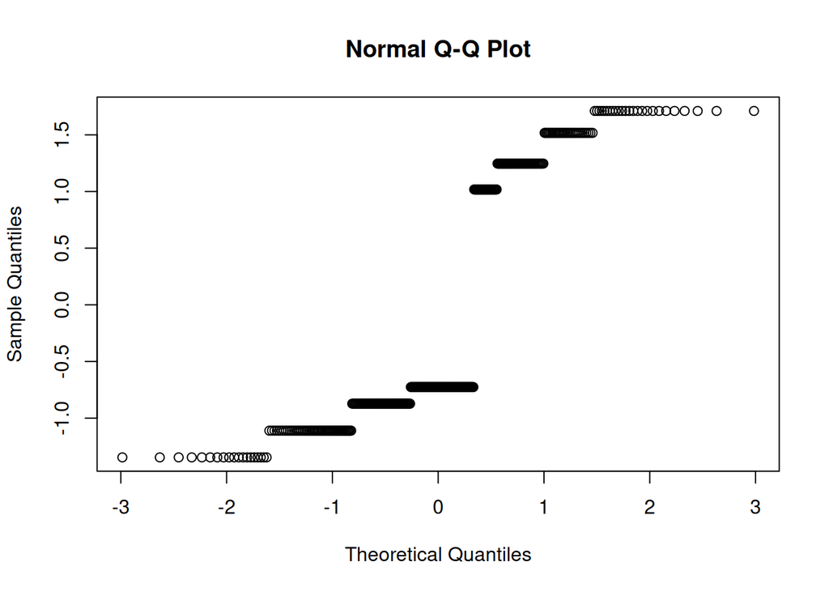

```r
qqnorm(resid(mod1))
```

```r
summary(glht(mod1,linfct = mcp(Type="Tukey")))
```

```
##
##   Simultaneous Tests for General Linear Hypotheses
##
## Multiple Comparisons of Means: Tukey Contrasts
##
##
## Fit: glm(formula = Presence_April_23 ~ Type, family = binomial, data = April_23)
##
## Linear Hypotheses:
##                          Estimate Std. Error z value Pr(>|z|)
## pavement - grass == 0      1.0396     0.3038   3.422  0.00363 **
## Tree bed - grass == 0      0.4293     0.3150   1.363  0.52031
## wall - grass == 0          1.5877     0.3747   4.237  < 0.001 ***
## Tree bed - pavement == 0  -0.6104     0.2957  -2.064  0.16340
## wall - pavement == 0       0.5481     0.3586   1.528  0.41774
## wall - Tree bed == 0       1.1585     0.3681   3.147  0.00908 **
## ---
## Signif. codes:  0 '***' 0.001 '**' 0.01 '*' 0.05 '.' 0.1 ' ' 1
## (Adjusted p values reported -- single-step method)
```

#### Compare April 2022 and April 2023

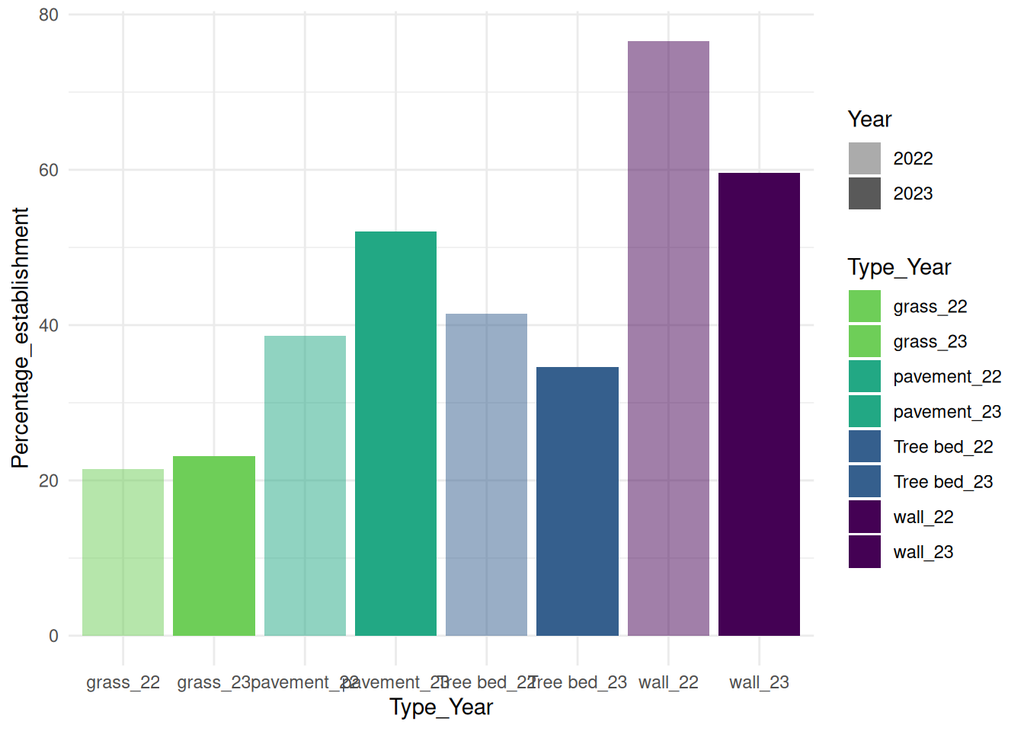

```r
# creating data frame for establishment percentage in one column
establishment2 <- data.frame("Year" = c("2023","2023","2023","2023","2022","2022","2022","2022"),"Type_Year" = c("grass_23","pavement_23","Tree bed_23","wall_23","grass_22","pavement_22","Tree bed_22","wall_22"), "Percentage_establishment" = c(establishment$Percentage_April23_S1, establishment$Percentage_April22))


#graph
colors <- c("#6ece58", "#6ece58", "#22a884", "#22a884", "#355f8d", "#355f8d", "#440154", "#440154")
ggplot(establishment2, aes(x = Type_Year ,y=Percentage_establishment, fill = Type_Year)) + geom_bar(aes(alpha = Year), stat = "identity") +
  theme_minimal() +  scale_discrete_manual(aesthetics = "fill", values =colors)+ scale_alpha_discrete(range = c(0.5,1))
```

```r
# model establishment over two generations (2021 sowing only)
# preparation of the data set
tmp1 <- April_22[,c(4,10)]
colnames(tmp1) <- c("Type", "Presence")
tmp1$Census_Year <- paste(tmp1$Type, "_", "2022")
tmp1$Year <- rep("2022")

tmp2 <- April_23[,c(4,11)]
colnames(tmp2) <- c("Type", "Presence")
tmp2$Census_Year <- paste(tmp2$Type, "_", "2023")
tmp2$Year <- rep("2023")

mod_Presence <- rbind(tmp1, tmp2)

mod3 <- glm(Presence ~ Type*Year, data = mod_Presence ,family = binomial)
summary(mod3)
```

```
##
## Call:
## glm(formula = Presence ~ Type * Year, family = binomial, data = mod_Presence)
##
## Coefficients:
##                       Estimate Std. Error z value Pr(>|z|)
## (Intercept)           -1.29578    0.22133  -5.854 4.79e-09 ***
## Typepavement           0.83396    0.29056   2.870  0.00410 **
## TypeTree bed           0.95284    0.29639   3.215  0.00131 **
## Typewall               2.48140    0.40948   6.060 1.36e-09 ***
## Year2023               0.09582    0.31786   0.301  0.76308
## Typepavement:Year2023  0.20566    0.42039   0.489  0.62470
## TypeTree bed:Year2023 -0.52358    0.43252  -1.211  0.22608
## Typewall:Year2023     -0.89367    0.55504  -1.610  0.10737
## ---
## Signif. codes:  0 '***' 0.001 '**' 0.01 '*' 0.05 '.' 0.1 ' ' 1
##
## (Dispersion parameter for binomial family taken to be 1)
##
##     Null deviance: 989.32  on 745  degrees of freedom
## Residual deviance: 920.33  on 738  degrees of freedom
## AIC: 936.33
##
## Number of Fisher Scoring iterations: 4
```

```r
anova(mod3,test="LRT")
```

```
## Analysis of Deviance Table
##
## Model: binomial, link: logit
##
## Response: Presence
##
## Terms added sequentially (first to last)
##
##
##           Df Deviance Resid. Df Resid. Dev  Pr(>Chi)
## NULL                        745     989.32
## Type       3   62.389       742     926.93 1.814e-13 ***
## Year       1    0.418       741     926.51    0.5179
## Type:Year  3    6.182       738     920.33    0.1031
## ---
## Signif. codes:  0 '***' 0.001 '**' 0.01 '*' 0.05 '.' 0.1 ' ' 1
```

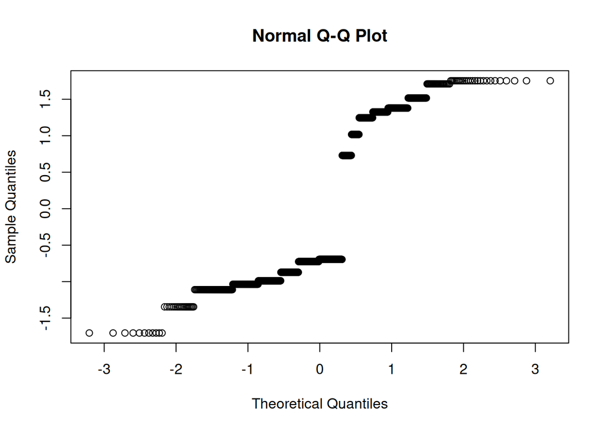

```r
qqnorm(resid(mod3))
```

```r
summary(glht(mod3,linfct = mcp(Type="Tukey")))
```

```
##
##   Simultaneous Tests for General Linear Hypotheses
##
## Multiple Comparisons of Means: Tukey Contrasts
##
##
## Fit: glm(formula = Presence ~ Type * Year, family = binomial, data = mod_Presence)
##
## Linear Hypotheses:
##                          Estimate Std. Error z value Pr(>|z|)
## pavement - grass == 0      0.8340     0.2906   2.870   0.0207 *
## Tree bed - grass == 0      0.9528     0.2964   3.215   0.0067 **
## wall - grass == 0          2.4814     0.4095   6.060   <0.001 ***
## Tree bed - pavement == 0   0.1189     0.2726   0.436   0.9716
## wall - pavement == 0       1.6474     0.3926   4.196   <0.001 ***
## wall - Tree bed == 0       1.5286     0.3969   3.851   <0.001 ***
## ---
## Signif. codes:  0 '***' 0.001 '**' 0.01 '*' 0.05 '.' 0.1 ' ' 1
## (Adjusted p values reported -- single-step method)
```

```r
#no interaction between type and census year
leastsquare = lsmeans(mod3, pairwise ~ Type,adjust = "tukey")
cld(leastsquare)
```

```
##  Type     lsmean    SE  df asymp.LCL asymp.UCL .group
##  grass    -1.248 0.159 Inf    -1.559   -0.9364  1
##  Tree bed -0.557 0.147 Inf    -0.844   -0.2694   2
##  pavement -0.311 0.138 Inf    -0.581   -0.0415   2
##  wall      0.787 0.228 Inf     0.341    1.2326    3
##
## Results are averaged over the levels of: Year
## Results are given on the logit (not the response) scale.
## Confidence level used: 0.95
## Results are given on the log odds ratio (not the response) scale.
## P value adjustment: tukey method for comparing a family of 4 estimates
## significance level used: alpha = 0.05
## NOTE: If two or more means share the same grouping symbol,
##       then we cannot show them to be different.
##       But we also did not show them to be the same.
```

### July 2022 sowing only

No environmental effects

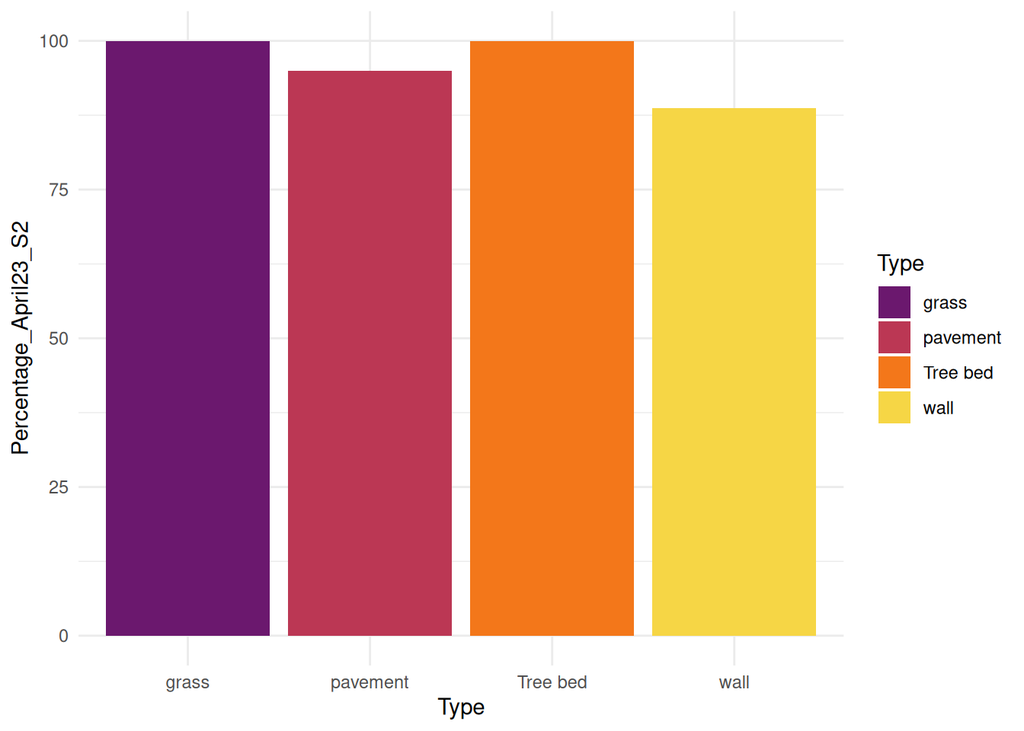

```r
# Number of site after removing the destroyed site before 05/2023
tmp <-as.data.frame( data_all %>% dplyr::filter(Destroyed == "Exist" | Destroyed =="04/2024") %>%
                 dplyr::filter(Sowing_1st =="07/2022") %>% count(Type))
establishment$Site_April23_S2 <- tmp[,2]

# Established sites
tmp <- as.data.frame(data_all %>% dplyr::filter(Destroyed == "Exist" | Destroyed =="04/2024") %>%
                       dplyr::filter(Sowing_1st =="07/2022") %>% dplyr::filter(Presence_April_23 == "Yes") %>% count(Type))
establishment$Established_April23_S2 <- tmp[,2]

establishment$Percentage_April23_S2 <- round(establishment$Established_April23_S2 / establishment$Site_April23_S2 * 100, digit = 2)
ggplot(establishment, aes(x = Type, y=Percentage_April23_S2, fill = Type)) + geom_bar(stat = "identity") +
  theme_minimal() + scale_fill_viridis(discrete = TRUE, begin = 0.3, end = 0.9, option = "B" )
```

```r
April_23_S2 <- as.data.frame( data_all %>% dplyr::filter(Destroyed == "Exist"| Destroyed =="04/2024") %>%
                             dplyr::filter(Sowing_1st =="07/2022") %>% dplyr::filter(Sowing_2nd =="no"))

mod1 <- glm(Presence_April_23 ~ Type, data = April_23_S2 ,family = binomial)
summary(mod1)
```

```
##
## Call:
## glm(formula = Presence_April_23 ~ Type, family = binomial, data = April_23_S2)
##
## Coefficients:
##                Estimate Std. Error z value Pr(>|z|)
## (Intercept)   1.857e+01  2.063e+03   0.009    0.993
## Typepavement -1.562e+01  2.063e+03  -0.008    0.994
## TypeTree bed  1.188e-08  6.841e+03   0.000    1.000
## Typewall     -1.651e+01  2.063e+03  -0.008    0.994
##
## (Dispersion parameter for binomial family taken to be 1)
##
##     Null deviance: 41.815  on 74  degrees of freedom
## Residual deviance: 39.097  on 71  degrees of freedom
## AIC: 47.097
##
## Number of Fisher Scoring iterations: 17
```

```r
anova(mod1, test="LRT")
```

```
## Analysis of Deviance Table
##
## Model: binomial, link: logit
##
## Response: Presence_April_23
##
## Terms added sequentially (first to last)
##
##
##      Df Deviance Resid. Df Resid. Dev Pr(>Chi)
## NULL                    74     41.815
## Type  3   2.7183        71     39.097   0.4371
```

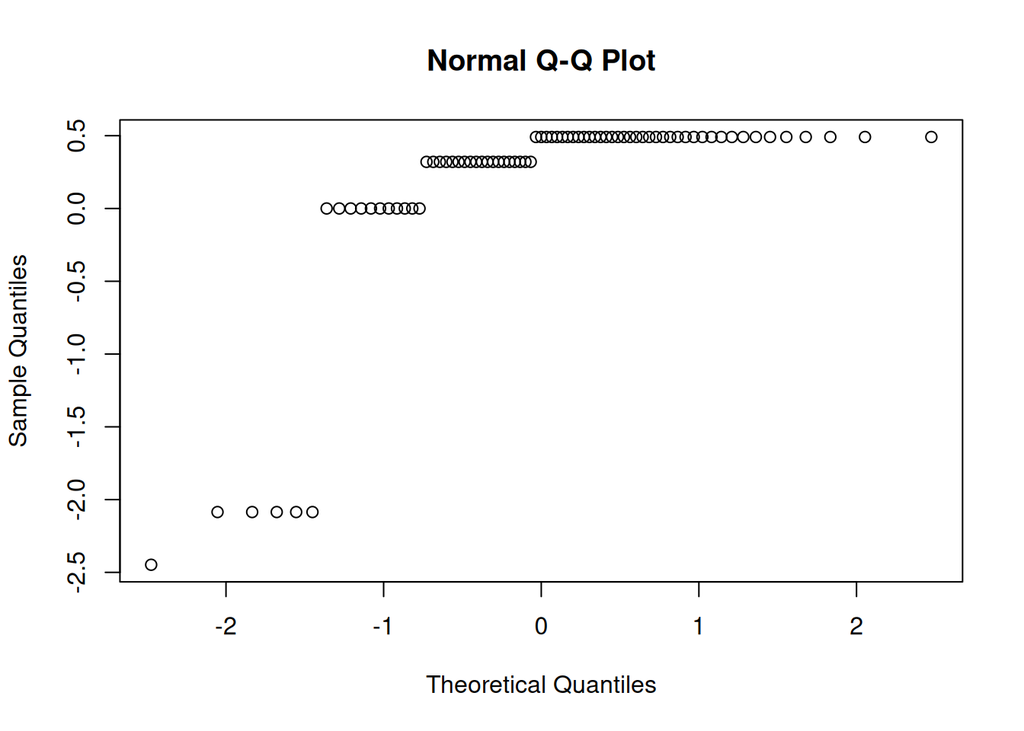

```r
qqnorm(resid(mod1))
```

### Comparing establishment between 2021 sowing and 2022 sowing

To compare both sowing we are going to compare the number of established individual over the total number of seed sown (2021 : 1 000 seeds, 2022 : 10 000 seeds)

```r
establishment_S1_S2  <- as.data.frame(data_all %>% dplyr::filter(Destroyed == "Exist" | Destroyed =="04/2024") %>%
                 dplyr::filter(Sowing_2nd =="no") %>% select(Site_ID, Type, Sowing_1st, April_23))

tmp<- establishment_S1_S2 %>% dplyr::filter(Sowing_1st =="09/2021") %>% mutate(April_23 / 1000 *100)
colnames(tmp) <- c("Site_ID", "Type", "Sowing_1st", "April_23", "Idv_establised")
tmp2 <- establishment_S1_S2 %>% dplyr::filter(Sowing_1st =="07/2022") %>% mutate(April_23 / 10000 *100)
colnames(tmp2) <- c("Site_ID", "Type", "Sowing_1st", "April_23", "Idv_establised")

establishment_S1_S2  <- rbind(tmp, tmp2)
establishment_S1_S2$Type_Year  <- paste(establishment_S1_S2$Type, "_", establishment_S1_S2$Sowing_1st)
establishment_S1_S2$Idv_establised <- as.numeric(establishment_S1_S2$Idv_establised)
```

For the graphic I removed the site with no established populations to be more easy to read.

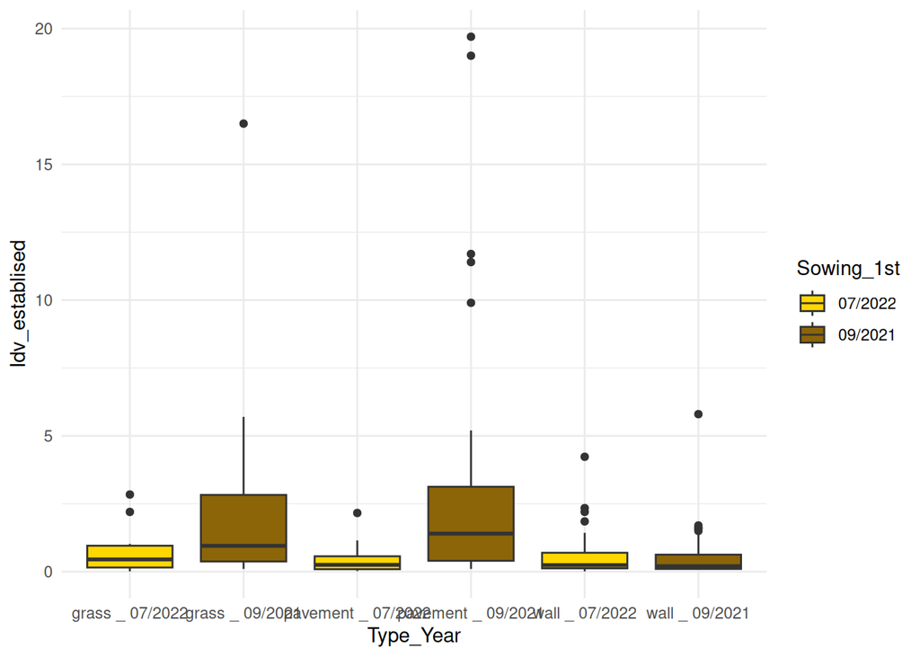

```r
colors <- c("gold1", "darkgoldenrod4")
establishment_S1_S2 %>% filter(Idv_establised >0) %>% filter(Type == "pavement" | Type =="grass" | Type =="wall") %>%
  ggplot( aes(x = Type_Year ,y=Idv_establised, fill = Sowing_1st)) + geom_boxplot() +  theme_minimal() +  scale_discrete_manual(aesthetics = "fill", values =colors)
```

For the model I kept the site with no population established

```r
mod2 <- glm.nb(Idv_establised ~  Type*Sowing_1st, data = establishment_S1_S2)

mod3 <- glm(Idv_establised ~ Type*Sowing_1st, data = establishment_S1_S2, family=negative.binomial(theta=mod2[["theta"]]))
summary(mod3)
```

```
##
## Call:
## glm(formula = Idv_establised ~ Type * Sowing_1st, family = negative.binomial(theta = mod2[["theta"]]),
##     data = establishment_S1_S2)
##
## Coefficients:
##                                Estimate Std. Error t value Pr(>|t|)
## (Intercept)                    -0.20334    0.84243  -0.241    0.809
## Typepavement                   -0.66893    1.07601  -0.622    0.534
## TypeTree bed                    0.04082    2.77997   0.015    0.988
## Typewall                       -0.46093    0.94943  -0.485    0.628
## Sowing_1st09/2021              -0.45881    0.88655  -0.518    0.605
## Typepavement:Sowing_1st09/2021  1.61099    1.13909   1.414    0.158
## TypeTree bed:Sowing_1st09/2021  0.92746    2.80517   0.331    0.741
## Typewall:Sowing_1st09/2021      0.21737    1.08219   0.201    0.841
##
## (Dispersion parameter for Negative Binomial(0.3111) family taken to be 1.59849)
##
##     Null deviance: 392.55  on 426  degrees of freedom
## Residual deviance: 368.38  on 419  degrees of freedom
##   (1 observation deleted due to missingness)
## AIC: 999.71
##
## Number of Fisher Scoring iterations: 7
```

```r
anova(mod3, test="LRT")
```

```
## Analysis of Deviance Table
##
## Model: Negative Binomial(0.3111), link: log
##
## Response: Idv_establised
##
## Terms added sequentially (first to last)
##
##
##                 Df Deviance Resid. Df Resid. Dev Pr(>Chi)
## NULL                              426     392.55
## Type             3  19.5889       423     372.96  0.00656 **
## Sowing_1st       1   0.1747       422     372.79  0.74094
## Type:Sowing_1st  3   4.4137       419     368.38  0.42993
## ---
## Signif. codes:  0 '***' 0.001 '**' 0.01 '*' 0.05 '.' 0.1 ' ' 1
```

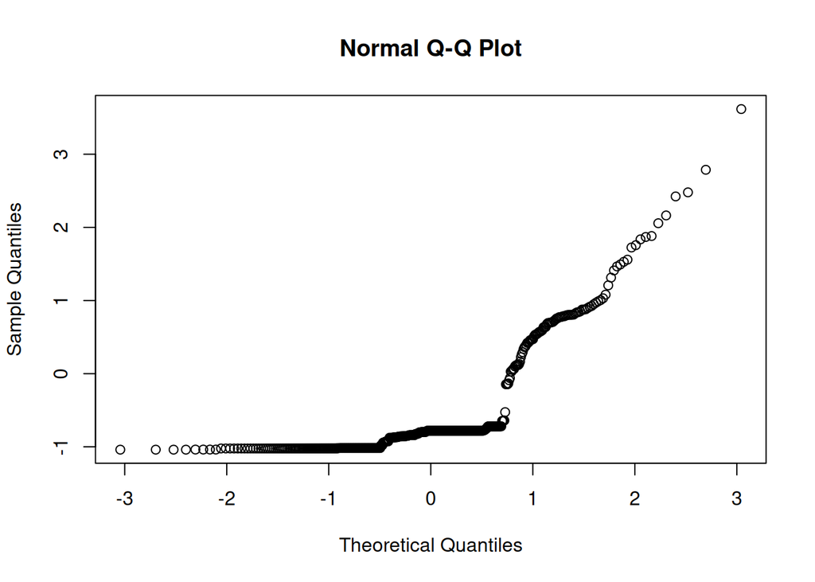

```r
qqnorm(resid(mod3))
```

Same ratio of seeds established per seed sown for both Sowing = same germinating rate

## April 2024

### September 2021 sowing only

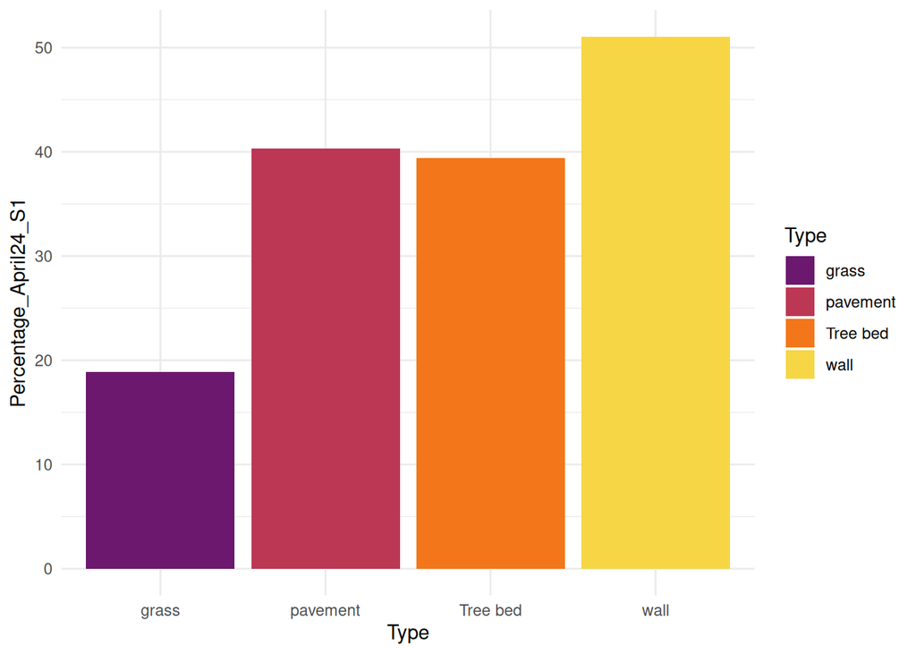

```r
# Number of site after removing the destroyed site before 05/2023
tmp <- as.data.frame( data_all %>% dplyr::filter(Destroyed == "Exist") %>%
                 dplyr::filter(Sowing_1st =="09/2021") %>% count(Type))
establishment$Site_April24_S1 <- tmp[,2]

# Established sites
tmp <- as.data.frame(data_all %>% dplyr::filter(Destroyed == "Exist") %>%
                       dplyr::filter(Sowing_1st =="09/2021") %>% dplyr::filter(Presence_April_24 == "Yes") %>% count(Type))
establishment$Established_April24_S1 <- tmp[,2]

# Percentage of establishment
establishment$Percentage_April24_S1 <- round(establishment$Established_April24_S1 / establishment$Site_April24_S1 * 100, digit = 2)

ggplot(establishment, aes(x = Type, y=Percentage_April24_S1, fill = Type)) + geom_bar(stat = "identity") +
  theme_minimal() + scale_fill_viridis(discrete = TRUE, begin = 0.3, end = 0.9, option = "B" )
```

Model Presence/absence

```r
April_24 <- as.data.frame( data_all %>% dplyr::filter(Destroyed == "Exist") %>%
                             dplyr::filter(Sowing_1st =="09/2021") %>% dplyr::filter(Sowing_2nd =="no"))

mod1 <- glm(Presence_April_24 ~ Type, data = April_24 ,family = binomial)
summary(mod1)
```

```
##
## Call:
## glm(formula = Presence_April_24 ~ Type, family = binomial, data = April_24)
##
## Coefficients:
##              Estimate Std. Error z value Pr(>|z|)
## (Intercept)   -1.4586     0.2482  -5.876 4.21e-09 ***
## Typepavement   0.8396     0.3249   2.584  0.00977 **
## TypeTree bed   0.8708     0.3257   2.674  0.00750 **
## Typewall       1.5012     0.3831   3.918 8.91e-05 ***
## ---
## Signif. codes:  0 '***' 0.001 '**' 0.01 '*' 0.05 '.' 0.1 ' ' 1
##
## (Dispersion parameter for binomial family taken to be 1)
##
##     Null deviance: 442.56  on 350  degrees of freedom
## Residual deviance: 425.04  on 347  degrees of freedom
## AIC: 433.04
##
## Number of Fisher Scoring iterations: 4
```

```r
anova(mod1, test="LRT")
```

```
## Analysis of Deviance Table
##
## Model: binomial, link: logit
##
## Response: Presence_April_24
##
## Terms added sequentially (first to last)
##
##
##      Df Deviance Resid. Df Resid. Dev  Pr(>Chi)
## NULL                   350     442.56
## Type  3   17.518       347     425.04 0.0005529 ***
## ---
## Signif. codes:  0 '***' 0.001 '**' 0.01 '*' 0.05 '.' 0.1 ' ' 1
```

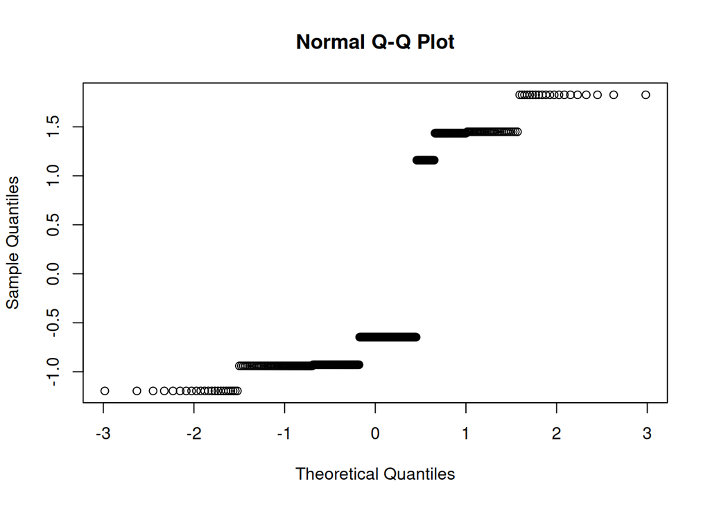

```r
qqnorm(resid(mod1))
```

```r
summary(glht(mod1,linfct = mcp(Type="Tukey")))
```

```
##
##   Simultaneous Tests for General Linear Hypotheses
##
## Multiple Comparisons of Means: Tukey Contrasts
##
##
## Fit: glm(formula = Presence_April_24 ~ Type, family = binomial, data = April_24)
##
## Linear Hypotheses:
##                          Estimate Std. Error z value Pr(>|z|)
## pavement - grass == 0     0.83958    0.32494   2.584   0.0476 *
## Tree bed - grass == 0     0.87083    0.32569   2.674   0.0368 *
## wall - grass == 0         1.50117    0.38311   3.918   <0.001 ***
## Tree bed - pavement == 0  0.03125    0.29732   0.105   0.9996
## wall - pavement == 0      0.66160    0.35931   1.841   0.2521
## wall - Tree bed == 0      0.63035    0.35999   1.751   0.2952
## ---
## Signif. codes:  0 '***' 0.001 '**' 0.01 '*' 0.05 '.' 0.1 ' ' 1
## (Adjusted p values reported -- single-step method)
```

#### Compare April 2022 2023 2024

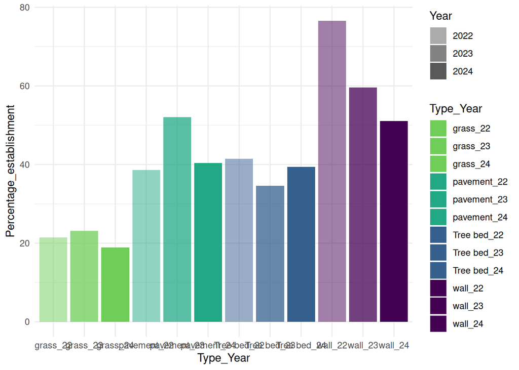

```r
# adding to data frame for establishment percentage in one column
tmp <- data.frame("Year" = c("2024","2024","2024","2024"),"Type_Year" = c("grass_24","pavement_24","Tree bed_24","wall_24"), "Percentage_establishment" = establishment$Percentage_April24_S1)
establishment2 <- rbind(tmp, establishment2)


colors <- c("#6ece58", "#6ece58", "#6ece58", "#22a884","#22a884", "#22a884", "#355f8d", "#355f8d",  "#355f8d", "#440154", "#440154", "#440154")
ggplot(establishment2, aes(x = Type_Year ,y=Percentage_establishment, fill = Type_Year)) + geom_bar(aes(alpha = Year), stat = "identity") +
  theme_minimal() +  scale_discrete_manual(aesthetics = "fill", values =colors)+ scale_alpha_discrete(range = c(0.5,1))
```

Model presence / absence mod with Years in random effect

```r
# preparation of the data set
tmp1 <- April_24[,c(4,12)]
colnames(tmp1) <- c("Type", "Presence")
tmp1$Census_Year <- paste(tmp1$Type, "_", "2024")
tmp1$Year <- rep("2024")

mod_Presence <- rbind(mod_Presence, tmp1)
mod_Presence$Census_Year <- as.factor(mod_Presence$Census_Year)

mod4 <- glmer(Presence ~ Type +(1|Year), data = mod_Presence ,family = binomial)
summary(mod4)
```

```
## Generalized linear mixed model fit by maximum likelihood (Laplace
##   Approximation) [glmerMod]
##  Family: binomial  ( logit )
## Formula: Presence ~ Type + (1 | Year)
##    Data: mod_Presence
##
##       AIC       BIC    logLik -2*log(L)  df.resid
##    1367.7    1392.7    -678.8    1357.7      1092
##
## Scaled residuals:
##     Min      1Q  Median      3Q     Max
## -1.3094 -0.7685 -0.5197  1.2116  1.9681
##
## Random effects:
##  Groups Name        Variance Std.Dev.
##  Year   (Intercept) 0.003719 0.06099
## Number of obs: 1097, groups:  Year, 3
##
## Fixed effects:
##              Estimate Std. Error z value Pr(>|z|)
## (Intercept)   -1.3158     0.1385  -9.499  < 2e-16 ***
## Typepavement   0.9002     0.1760   5.115 3.14e-07 ***
## TypeTree bed   0.7574     0.1795   4.221 2.44e-05 ***
## Typewall       1.8233     0.2196   8.302  < 2e-16 ***
## ---
## Signif. codes:  0 '***' 0.001 '**' 0.01 '*' 0.05 '.' 0.1 ' ' 1
##
## Correlation of Fixed Effects:
##             (Intr) Typpvm TypTrb
## Typepavemnt -0.734
## TypeTreebed -0.721  0.566
## Typewall    -0.590  0.463  0.455
```

```r
car::Anova(mod4, type=3)
```

```
## Analysis of Deviance Table (Type III Wald chisquare tests)
##
## Response: Presence
##              Chisq Df Pr(>Chisq)
## (Intercept) 90.236  1  < 2.2e-16 ***
## Type        71.013  3  2.591e-15 ***
## ---
## Signif. codes:  0 '***' 0.001 '**' 0.01 '*' 0.05 '.' 0.1 ' ' 1
```

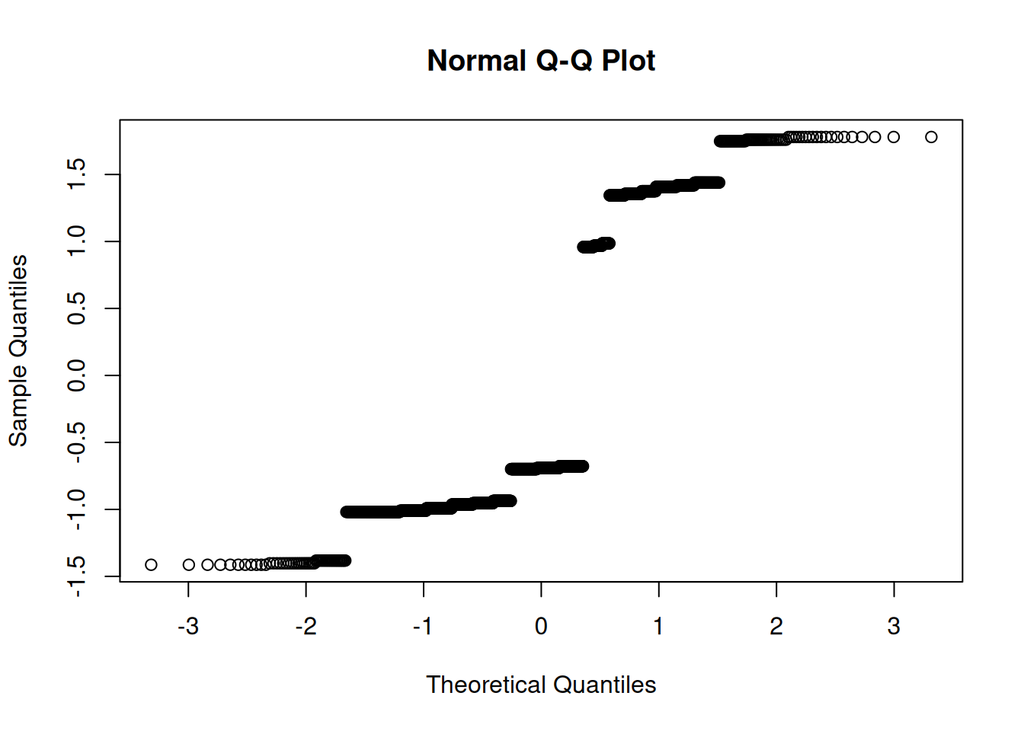

```r
qqnorm(resid(mod4))
```

```r
summary(glht(mod4,linfct = mcp(Type="Tukey")))
```

```
##
##   Simultaneous Tests for General Linear Hypotheses
##
## Multiple Comparisons of Means: Tukey Contrasts
##
##
## Fit: glmer(formula = Presence ~ Type + (1 | Year), data = mod_Presence,
##     family = binomial)
##
## Linear Hypotheses:
##                          Estimate Std. Error z value Pr(>|z|)
## pavement - grass == 0      0.9002     0.1760   5.115  < 1e-04 ***
## Tree bed - grass == 0      0.7574     0.1795   4.221 0.000145 ***
## wall - grass == 0          1.8233     0.2196   8.302  < 1e-04 ***
## Tree bed - pavement == 0  -0.1428     0.1656  -0.862 0.822478
## wall - pavement == 0       0.9231     0.2084   4.430  < 1e-04 ***
## wall - Tree bed == 0       1.0659     0.2112   5.047  < 1e-04 ***
## ---
## Signif. codes:  0 '***' 0.001 '**' 0.01 '*' 0.05 '.' 0.1 ' ' 1
## (Adjusted p values reported -- single-step method)
```

```r
#no interaction between type and census year
leastsquare = lsmeans(mod4, pairwise ~ Type,adjust = "tukey")
cld(leastsquare)
```

```
##  Type     lsmean    SE  df asymp.LCL asymp.UCL .group
##  grass    -1.316 0.139 Inf    -1.587    -1.044  1
##  Tree bed -0.558 0.125 Inf    -0.803    -0.314   2
##  pavement -0.416 0.120 Inf    -0.651    -0.180   2
##  wall      0.508 0.177 Inf     0.160     0.855    3
##
## Results are given on the logit (not the response) scale.
## Confidence level used: 0.95
## Results are given on the log odds ratio (not the response) scale.
## P value adjustment: tukey method for comparing a family of 4 estimates
## significance level used: alpha = 0.05
## NOTE: If two or more means share the same grouping symbol,
##       then we cannot show them to be different.
##       But we also did not show them to be the same.
```

Model presence / absence mod with Years in nested effects

```r
mod5 <- glm(Presence ~ Type*Year, data = mod_Presence ,family = binomial)
summary(mod5)
```

```
##
## Call:
## glm(formula = Presence ~ Type * Year, family = binomial, data = mod_Presence)
##
## Coefficients:
##                        Estimate Std. Error z value Pr(>|z|)
## (Intercept)           -1.295780   0.221332  -5.854 4.79e-09 ***
## Typepavement           0.833962   0.290561   2.870  0.00410 **
## TypeTree bed           0.952836   0.296385   3.215  0.00131 **
## Typewall               2.481404   0.409481   6.060 1.36e-09 ***
## Year2023               0.095816   0.317861   0.301  0.76308
## Year2024              -0.162835   0.332589  -0.490  0.62442
## Typepavement:Year2023  0.205660   0.420394   0.489  0.62470
## TypeTree bed:Year2023 -0.523576   0.432522  -1.211  0.22608
## Typewall:Year2023     -0.893674   0.555039  -1.610  0.10737
## Typepavement:Year2024  0.005614   0.435901   0.013  0.98973
## TypeTree bed:Year2024 -0.082007   0.440359  -0.186  0.85227
## Typewall:Year2024     -0.980229   0.560756  -1.748  0.08046 .
## ---
## Signif. codes:  0 '***' 0.001 '**' 0.01 '*' 0.05 '.' 0.1 ' ' 1
##
## (Dispersion parameter for binomial family taken to be 1)
##
##     Null deviance: 1434.8  on 1096  degrees of freedom
## Residual deviance: 1345.4  on 1085  degrees of freedom
## AIC: 1369.4
##
## Number of Fisher Scoring iterations: 4
```

```r
car::Anova(mod5)
```

```
## Analysis of Deviance Table (Type II tests)
##
## Response: Presence
##           LR Chisq Df Pr(>Chisq)
## Type        77.739  3     <2e-16 ***
## Year         3.888  2     0.1431
## Type:Year    8.497  6     0.2039
## ---
## Signif. codes:  0 '***' 0.001 '**' 0.01 '*' 0.05 '.' 0.1 ' ' 1
```

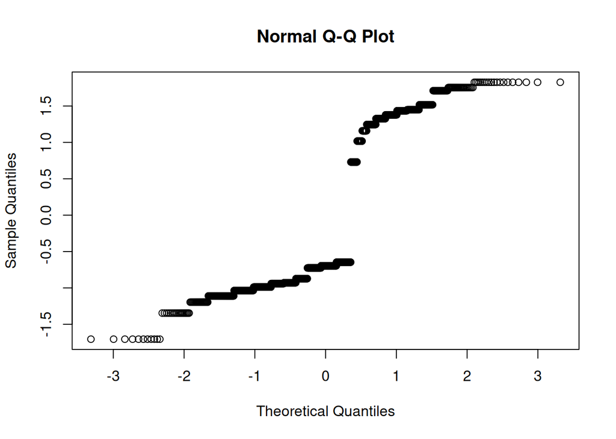

```r
qqnorm(resid(mod5))
```

```r
summary(glht(mod5,linfct = mcp(Type="Tukey")))
```

```
##
##   Simultaneous Tests for General Linear Hypotheses
##
## Multiple Comparisons of Means: Tukey Contrasts
##
##
## Fit: glm(formula = Presence ~ Type * Year, family = binomial, data = mod_Presence)
##
## Linear Hypotheses:
##                          Estimate Std. Error z value Pr(>|z|)
## pavement - grass == 0      0.8340     0.2906   2.870  0.02043 *
## Tree bed - grass == 0      0.9528     0.2964   3.215  0.00701 **
## wall - grass == 0          2.4814     0.4095   6.060  < 0.001 ***
## Tree bed - pavement == 0   0.1189     0.2726   0.436  0.97157
## wall - pavement == 0       1.6474     0.3926   4.196  < 0.001 ***
## wall - Tree bed == 0       1.5286     0.3969   3.851  < 0.001 ***
## ---
## Signif. codes:  0 '***' 0.001 '**' 0.01 '*' 0.05 '.' 0.1 ' ' 1
## (Adjusted p values reported -- single-step method)
```

```r
#no interaction between type and census year
leastsquare = lsmeans(mod5, pairwise ~ Type*Year,adjust = "tukey")
cld(leastsquare)
```

```
##  Type     Year  lsmean    SE  df asymp.LCL asymp.UCL .group
##  grass    2024 -1.4586 0.248 Inf    -1.945   -0.9721  1
##  grass    2022 -1.2958 0.221 Inf    -1.730   -0.8620  12
##  grass    2023 -1.2000 0.228 Inf    -1.647   -0.7528  12
##  Tree bed 2023 -0.7707 0.217 Inf    -1.196   -0.3450  123
##  pavement 2024 -0.6190 0.210 Inf    -1.030   -0.2081  123
##  Tree bed 2024 -0.5878 0.211 Inf    -1.001   -0.1746  123
##  pavement 2022 -0.4618 0.188 Inf    -0.831   -0.0929  123
##  Tree bed 2022 -0.3429 0.197 Inf    -0.729    0.0434   23
##  pavement 2023 -0.1603 0.201 Inf    -0.554    0.2329    3
##  wall     2024  0.0426 0.292 Inf    -0.529    0.6145    34
##  wall     2023  0.3878 0.297 Inf    -0.195    0.9703    34
##  wall     2022  1.1856 0.345 Inf     0.510    1.8608     4
##
## Results are given on the logit (not the response) scale.
## Confidence level used: 0.95
## Results are given on the log odds ratio (not the response) scale.
## P value adjustment: tukey method for comparing a family of 12 estimates
## significance level used: alpha = 0.05
## NOTE: If two or more means share the same grouping symbol,
##       then we cannot show them to be different.
##       But we also did not show them to be the same.
```

```r
mod5_emm <- emmeans::ref_grid(mod5)
emm <- emmeans::emmeans(mod5_emm, ~ Year | Type)
pairs(emm )
```

```
## Type = grass:
##  contrast            estimate    SE  df z.ratio p.value
##  Year2022 - Year2023  -0.0958 0.318 Inf  -0.301  0.9511
##  Year2022 - Year2024   0.1628 0.333 Inf   0.490  0.8763
##  Year2023 - Year2024   0.2587 0.337 Inf   0.767  0.7232
##
## Type = pavement:
##  contrast            estimate    SE  df z.ratio p.value
##  Year2022 - Year2023  -0.3015 0.275 Inf  -1.096  0.5167
##  Year2022 - Year2024   0.1572 0.282 Inf   0.558  0.8424
##  Year2023 - Year2024   0.4587 0.290 Inf   1.581  0.2540
##
## Type = Tree bed:
##  contrast            estimate    SE  df z.ratio p.value
##  Year2022 - Year2023   0.4278 0.293 Inf   1.458  0.3112
##  Year2022 - Year2024   0.2448 0.289 Inf   0.848  0.6729
##  Year2023 - Year2024  -0.1829 0.303 Inf  -0.604  0.8178
##
## Type = wall:
##  contrast            estimate    SE  df z.ratio p.value
##  Year2022 - Year2023   0.7979 0.455 Inf   1.754  0.1855
##  Year2022 - Year2024   1.1431 0.451 Inf   2.532  0.0305
##  Year2023 - Year2024   0.3452 0.417 Inf   0.829  0.6851
##
## Results are given on the log odds ratio (not the response) scale.
## P value adjustment: tukey method for comparing a family of 3 estimates
```

```r
emm <- emmeans::emmeans(mod5_emm, ~ Type)
pairs(emm )
```

```
##  contrast            estimate    SE  df z.ratio p.value
##  grass - pavement      -0.904 0.177 Inf  -5.106  <.0001
##  grass - Tree bed      -0.751 0.180 Inf  -4.161  0.0002
##  grass - wall          -1.857 0.225 Inf  -8.259  <.0001
##  pavement - Tree bed    0.153 0.167 Inf   0.920  0.7940
##  pavement - wall       -0.952 0.214 Inf  -4.452  0.0001
##  Tree bed - wall       -1.106 0.217 Inf  -5.103  <.0001
##
## Results are averaged over the levels of: Year
## Results are given on the log odds ratio (not the response) scale.
## P value adjustment: tukey method for comparing a family of 4 estimates
```

### July 2022 sowing only

No environmental effects

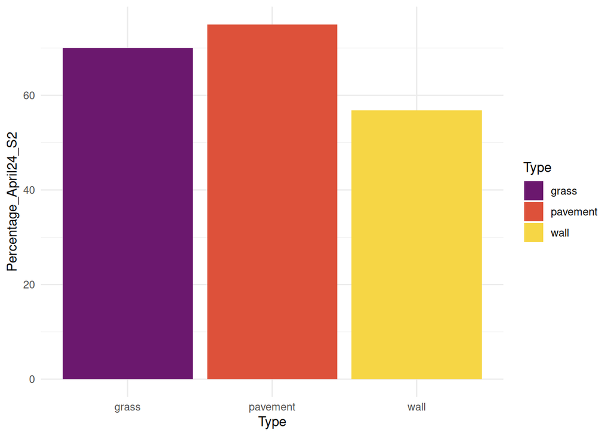

```r
# Number of site after removing the destroyed site before 05/2023
tmp <-as.data.frame( data_all %>% dplyr::filter(Destroyed == "Exist") %>%
                 dplyr::filter(Sowing_1st =="07/2022") %>% count(Type))
establishment$Site_April24_S2 <- tmp[,2]

# Established sites
tmp <- as.data.frame(data_all %>% dplyr::filter(Destroyed == "Exist") %>%
                       dplyr::filter(Sowing_1st =="07/2022") %>% dplyr::filter(Presence_April_24 == "Yes") %>% count(Type))

tmp <- rbind(tmp[1:2,],c("Tree bed", 0),tmp[-(1:2),])
establishment$Established_April24_S2 <- tmp[,2]
establishment$Established_April24_S2 <- as.numeric(establishment$Established_April24_S2)

establishment$Percentage_April24_S2 <- round(establishment$Established_April24_S2 / establishment$Site_April24_S2 * 100, digit = 2)

establishment %>% filter(Type != "Tree bed") %>%
  ggplot(aes(x = Type, y=Percentage_April24_S2, fill = Type)) + geom_bar(stat = "identity") +
  theme_minimal() + scale_fill_viridis(discrete = TRUE, begin = 0.3, end = 0.9, option = "B" )
```

```r
April_24_S2 <- as.data.frame( data_all %>% dplyr::filter(Destroyed == "Exist") %>%
                             dplyr::filter(Sowing_1st =="07/2022") %>% dplyr::filter(Sowing_2nd =="no"))

mod1 <- glm(Presence_April_24 ~ Type, data = April_24_S2 ,family = binomial)
summary(mod1)
```

```
##
## Call:
## glm(formula = Presence_April_24 ~ Type, family = binomial, data = April_24_S2)
##
## Coefficients:
##               Estimate Std. Error z value Pr(>|z|)
## (Intercept)     0.8473     0.6901   1.228    0.220
## Typepavement    0.2513     0.8619   0.292    0.771
## TypeTree bed  -16.4134  1455.3977  -0.011    0.991
## Typewall       -0.5729     0.7542  -0.760    0.448
##
## (Dispersion parameter for binomial family taken to be 1)
##
##     Null deviance: 99.106  on 74  degrees of freedom
## Residual deviance: 94.887  on 71  degrees of freedom
## AIC: 102.89
##
## Number of Fisher Scoring iterations: 14
```

```r
anova(mod1, test="LRT")
```

```
## Analysis of Deviance Table
##
## Model: binomial, link: logit
##
## Response: Presence_April_24
##
## Terms added sequentially (first to last)
##
##
##      Df Deviance Resid. Df Resid. Dev Pr(>Chi)
## NULL                    74     99.106
## Type  3    4.219        71     94.887   0.2388
```

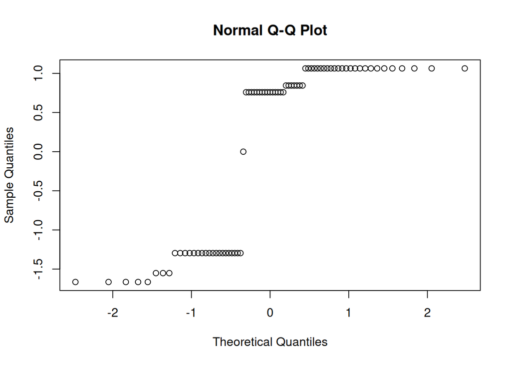

```r
qqnorm(resid(mod1))
```

#### Comparing April 2023 and April 2024

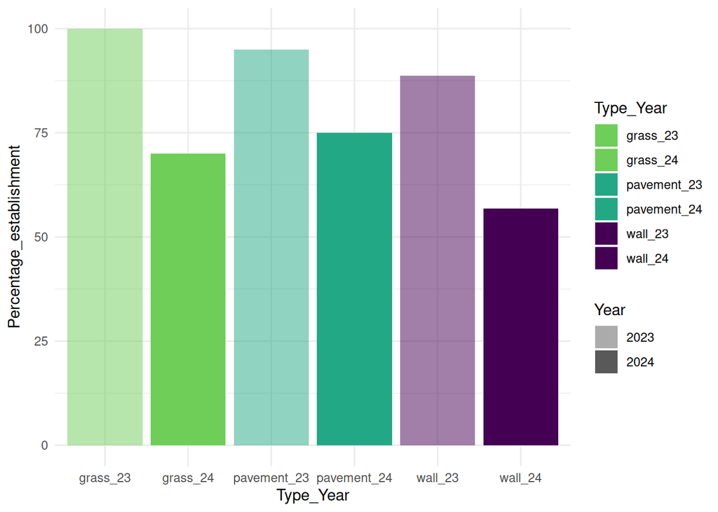

```r
# adding to data frame for establishment percentage in one column
establishment2  <- data.frame("Type" = c("grass","pavement","Tree bed","wall","grass","pavement","Tree bed","wall"),
                  "Year" = c("2023","2023","2023","2023","2024","2024","2024","2024"),
                  "Type_Year" = c("grass_23","pavement_23","Tree bed_23","wall_23","grass_24","pavement_24","Tree bed_24","wall_24"),
                  "Percentage_establishment" = c(establishment$Percentage_April23_S2,establishment$Percentage_April24_S2))


colors <- c("#6ece58", "#6ece58","#22a884", "#22a884", "#440154", "#440154")
establishment2 %>% filter(Type != "Tree bed") %>%
  ggplot( aes(x = Type_Year ,y=Percentage_establishment, fill = Type_Year)) + geom_bar(aes(alpha = Year), stat = "identity") +
  theme_minimal() +  scale_discrete_manual(aesthetics = "fill", values =colors)+ scale_alpha_discrete(range = c(0.5,1))
```

```r
# preparation of the data set
tmp1 <- April_23_S2[,c(4,11)]
colnames(tmp1) <- c("Type", "Presence")
tmp1$Census_Year <- paste(tmp1$Type, "_", "2023")
tmp1$Year <- rep("2023")

tmp2 <- April_24[,c(4,12)]
colnames(tmp2) <- c("Type", "Presence")
tmp2$Census_Year <- paste(tmp2$Type, "_", "2024")
tmp2$Year <- rep("2024")

mod_Presence <- rbind(tmp1, tmp2)

mod_Presence <- mod_Presence %>% filter(Type != "Tree bed")

mod3 <- glm(Presence ~ Type*Year, data = mod_Presence ,family = binomial)
summary(mod3)
```

```
##
## Call:
## glm(formula = Presence ~ Type * Year, family = binomial, data = mod_Presence)
##
## Coefficients:
##                       Estimate Std. Error z value Pr(>|z|)
## (Intercept)              16.57     758.80   0.022    0.983
## Typepavement            -13.62     758.80  -0.018    0.986
## Typewall                -14.51     758.80  -0.019    0.985
## Year2024                -18.02     758.80  -0.024    0.981
## Typepavement:Year2024    14.46     758.80   0.019    0.985
## Typewall:Year2024        16.01     758.80   0.021    0.983
##
## (Dispersion parameter for binomial family taken to be 1)
##
##     Null deviance: 449.98  on 326  degrees of freedom
## Residual deviance: 336.39  on 321  degrees of freedom
## AIC: 348.39
##
## Number of Fisher Scoring iterations: 15
```

```r
anova(mod3,test="LRT")
```

```
## Analysis of Deviance Table
##
## Model: binomial, link: logit
##
## Response: Presence
##
## Terms added sequentially (first to last)
##
##
##           Df Deviance Resid. Df Resid. Dev  Pr(>Chi)
## NULL                        326     449.98
## Type       2   39.878       324     410.10 2.191e-09 ***
## Year       1   66.961       323     343.14 2.769e-16 ***
## Type:Year  2    6.750       321     336.39   0.03421 *
## ---
## Signif. codes:  0 '***' 0.001 '**' 0.01 '*' 0.05 '.' 0.1 ' ' 1
```

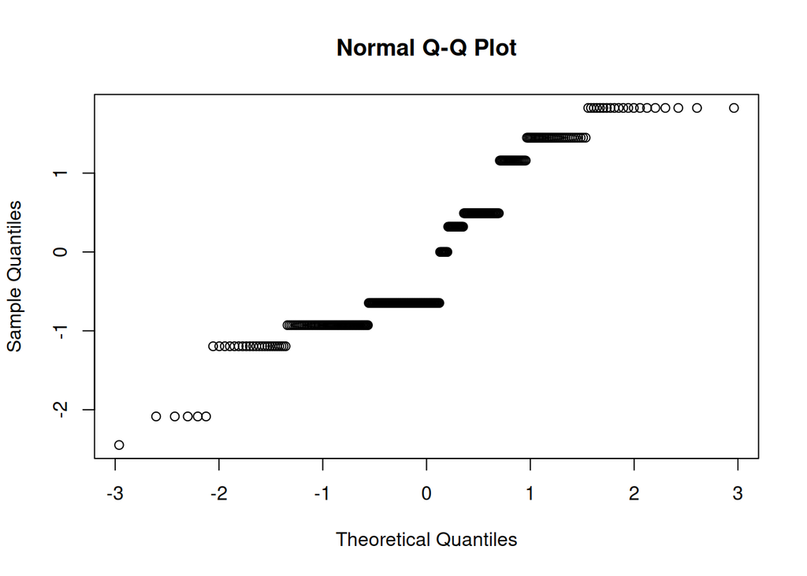

```r
qqnorm(resid(mod3))
```

```r
mod3_emm <- emmeans::ref_grid(mod3)
emm <- emmeans::emmeans(mod3_emm, ~ Year | Type)
pairs(emm )
```

```
## Type = grass:
##  contrast            estimate      SE  df z.ratio p.value
##  Year2023 - Year2024    18.02 759.000 Inf   0.024  0.9810
##
## Type = pavement:
##  contrast            estimate      SE  df z.ratio p.value
##  Year2023 - Year2024     3.56   1.050 Inf   3.403  0.0007
##
## Type = wall:
##  contrast            estimate      SE  df z.ratio p.value
##  Year2023 - Year2024     2.01   0.558 Inf   3.608  0.0003
##
## Results are given on the log odds ratio (not the response) scale.
```

### Comparing establishment between 2021 sowing and 2022 sowing

#### April 2024 only

To compare both sowing we are going to compare the number of established individual over the total number of seed sown (2021 : 1 000 seeds, 2022 : 10 000 seeds)

```r
tmp  <- as.data.frame(data_all %>% dplyr::filter(Destroyed == "Exist") %>%
                 dplyr::filter(Sowing_2nd =="no") %>% select(Site_ID, Type, Sowing_1st, EndMarch_24))

tmp1<- tmp %>% dplyr::filter(Sowing_1st =="09/2021") %>% mutate(EndMarch_24 / 1000 *100)
colnames(tmp1) <- c("Site_ID", "Type", "Sowing_1st", "April_24", "Idv_establised_24")

tmp2 <- tmp %>% dplyr::filter(Sowing_1st =="07/2022") %>% mutate(EndMarch_24 / 10000 *100)
colnames(tmp2) <- c("Site_ID", "Type", "Sowing_1st", "April_24", "Idv_establised_24")

tmp  <- rbind(tmp1, tmp2)
tmp  <- rbind(tmp, c("364", "grass", "09/2021", NA, NA), c(c("365", "grass", "09/2021", NA, NA)))
establishment_S1_S2 <- merge(establishment_S1_S2, tmp[,c(1,4,5)], by = "Site_ID")
establishment_S1_S2$Idv_establised_24 <- as.numeric(establishment_S1_S2$Idv_establised_24 )
```

For the graphic I removed the site with no established populations to be more easy to read.

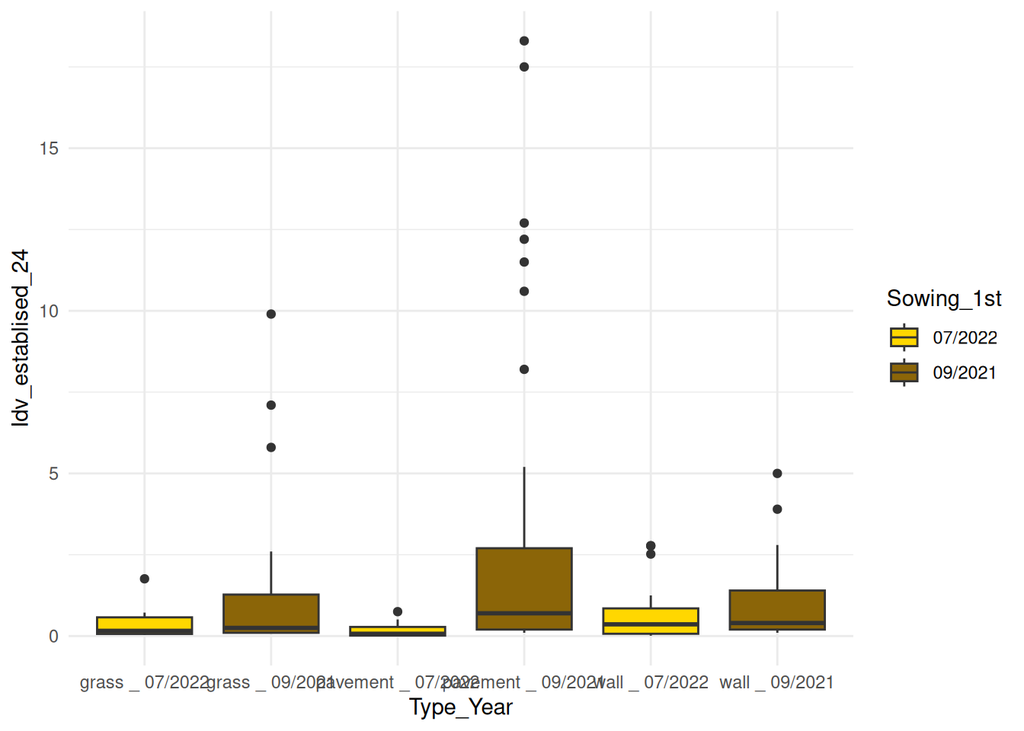

```r
colors <- c("gold1", "darkgoldenrod4")
establishment_S1_S2 %>% filter(Idv_establised_24 >0) %>% filter(Type == "pavement" | Type =="grass" | Type =="wall") %>%
  ggplot( aes(x = Type_Year ,y=Idv_establised_24, fill = Sowing_1st)) + geom_boxplot() +  theme_minimal() +  scale_discrete_manual(aesthetics = "fill", values =colors)
```

For the model I kept the site with no population established

```r
establishment_S1_S2_mod <- establishment_S1_S2 %>% filter(Type != "Tree bed")

mod2 <- glm.nb(Idv_establised_24 ~  Type*Sowing_1st, data = establishment_S1_S2_mod)

mod3 <- glm(Idv_establised_24 ~ Type*Sowing_1st, data = establishment_S1_S2_mod, family=negative.binomial(theta=mod2[["theta"]]))
summary(mod3)
```

```
##
## Call:
## glm(formula = Idv_establised_24 ~ Type * Sowing_1st, family = negative.binomial(theta = mod2[["theta"]]),
##     data = establishment_S1_S2_mod)
##
## Coefficients:
##                                Estimate Std. Error t value Pr(>|t|)
## (Intercept)                    -1.13010    1.07601  -1.050    0.294
## Typepavement                   -0.85403    1.44047  -0.593    0.554
## Typewall                        0.17441    1.18435   0.147    0.883
## Sowing_1st09/2021              -0.07073    1.12716  -0.063    0.950
## Typepavement:Sowing_1st09/2021  2.19810    1.50576   1.460    0.145
## Typewall:Sowing_1st09/2021      0.42665    1.31065   0.326    0.745
##
## (Dispersion parameter for Negative Binomial(0.2468) family taken to be 1.61971)
##
##     Null deviance: 258.84  on 326  degrees of freedom
## Residual deviance: 236.45  on 321  degrees of freedom
##   (2 observations deleted due to missingness)
## AIC: 585.86
##
## Number of Fisher Scoring iterations: 8
```

```r
anova(mod3, test="LRT")
```

```
## Analysis of Deviance Table
##
## Model: Negative Binomial(0.2468), link: log
##
## Response: Idv_establised_24
##
## Terms added sequentially (first to last)
##
##
##                 Df Deviance Resid. Df Resid. Dev Pr(>Chi)
## NULL                              326     258.84
## Type             2  14.3171       324     244.52  0.01204 *
## Sowing_1st       1   3.3911       323     241.13  0.14791
## Type:Sowing_1st  2   4.6766       321     236.45  0.23606
## ---
## Signif. codes:  0 '***' 0.001 '**' 0.01 '*' 0.05 '.' 0.1 ' ' 1
```

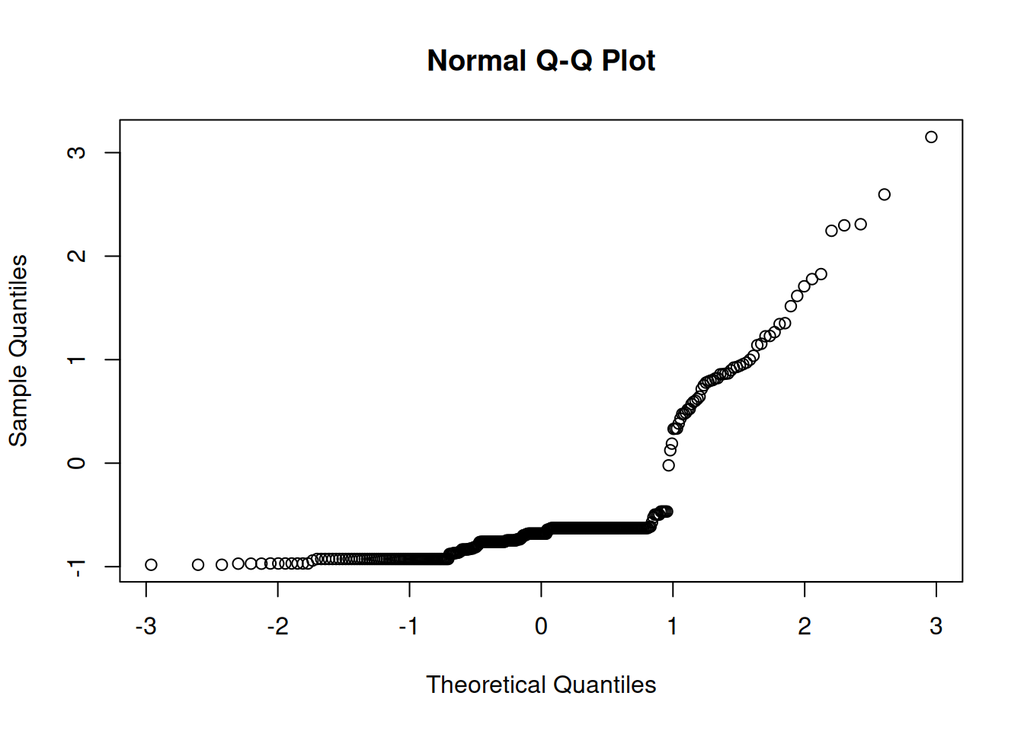

```r
qqnorm(resid(mod3))
```

```r
summary(glht(mod3,linfct = mcp(Type="Tukey")))
```

```
##
##   Simultaneous Tests for General Linear Hypotheses
##
## Multiple Comparisons of Means: Tukey Contrasts
##
##
## Fit: glm(formula = Idv_establised_24 ~ Type * Sowing_1st, family = negative.binomial(theta = mod2[["theta"]]),
##     data = establishment_S1_S2_mod)
##
## Linear Hypotheses:
##                       Estimate Std. Error z value Pr(>|z|)
## pavement - grass == 0  -0.8540     1.4405  -0.593    0.821
## wall - grass == 0       0.1744     1.1844   0.147    0.988
## wall - pavement == 0    1.0284     1.0780   0.954    0.600
## (Adjusted p values reported -- single-step method)
```

```r
#no interaction between type and census year
leastsquare = lsmeans(mod3, pairwise ~ Type*Sowing_1st,adjust = "tukey")
cld(leastsquare)
```

```
##  Type     Sowing_1st lsmean    SE  df asymp.LCL asymp.UCL .group
##  pavement 07/2022    -1.984 0.958 Inf     -3.86   -0.1071  12
##  grass    09/2021    -1.201 0.336 Inf     -1.86   -0.5429  1
##  grass    07/2022    -1.130 1.080 Inf     -3.24    0.9788  12
##  wall     07/2022    -0.956 0.495 Inf     -1.93    0.0142  12
##  wall     09/2021    -0.600 0.450 Inf     -1.48    0.2820  12
##  pavement 09/2021     0.143 0.282 Inf     -0.41    0.6964   2
##
## Results are given on the log (not the response) scale.
## Confidence level used: 0.95
## P value adjustment: tukey method for comparing a family of 6 estimates
## significance level used: alpha = 0.05
## NOTE: If two or more means share the same grouping symbol,
##       then we cannot show them to be different.
##       But we also did not show them to be the same.
```